# LA INFLUENCIA DE LA TECNOLOGÍA EN EL ENTORNO SOCIAL DE LOS ESTUDIANTES DE UTEC DURANTE EL SEMESTRE 2023-1

## 2.2 MOSAICO : Variable Manera de socializar y sexo

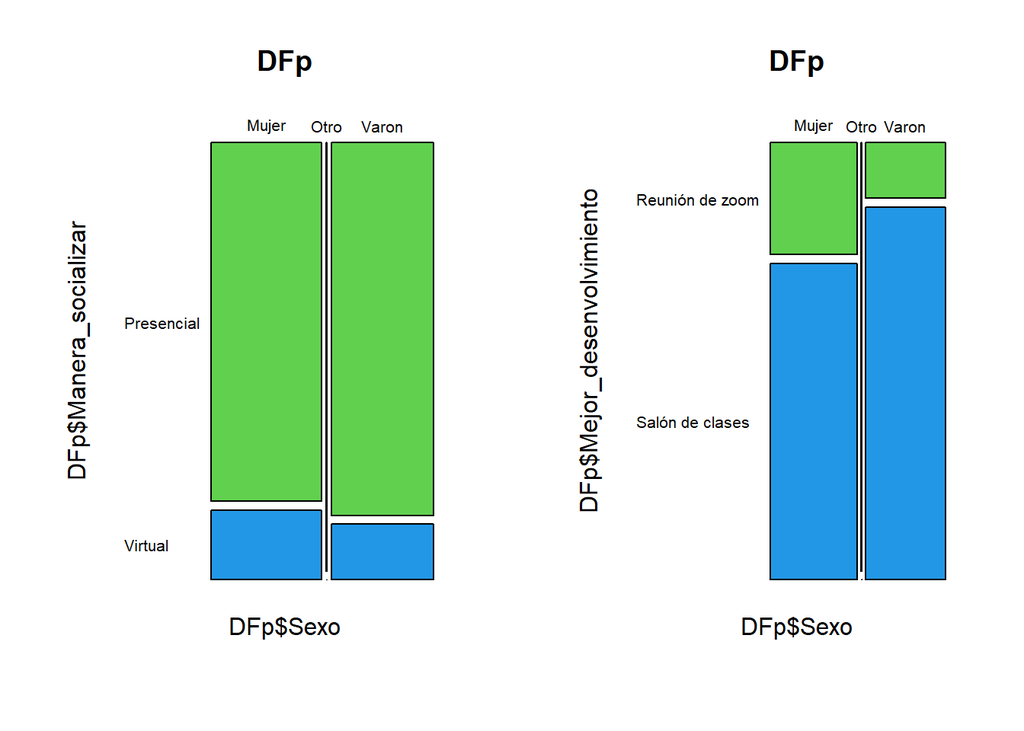

```r
library(stats)
library(ggplot2)

#de que manera prefieres socializar porcentaje de hombres y mujeres
par(mfrow=c(1,2))
mosaicplot(~DFp$Sexo + DFp$Manera_socializar,
           data=DFp,
           color=3:7,
           las=1)
mosaicplot(~DFp$Sexo + DFp$Mejor_desenvolvimiento,
           data=DFp,
           color=3:7,
           las=1)
```

Interpretación:

En estos gráficos se puede observar que en el primero se comparan la cantidad de varones y mujeres que prefieren socializar de manera presencial o virtual del periodo 2023-1, donde se ve que en gran porcentaje tanto varones como mujeres prefieren socializar de manera presencial siendo algo mayor el de los varones. En el segundo se comparan qué cantidad de hombres y mujeres sienten que se desenvuelven mejor, si en un salón de clase o en una reunión de zoom, por los datos en la gráfica se puede ver tanto varones como mujeres siente que se desenvuelven mejor en un salón de clases, aunque en mayor porcentaje los varones.

Esto se relaciona con el objetivo general debido a que sirve para analizar que la tecnología ha sido de gran importancia últimamente, pero aun la personas para su entorno social siguen prefiriendo las interacciones físicas.

## 2.3 GRÁFICO DE BARRAS: Sociable antes y después de la pandemia

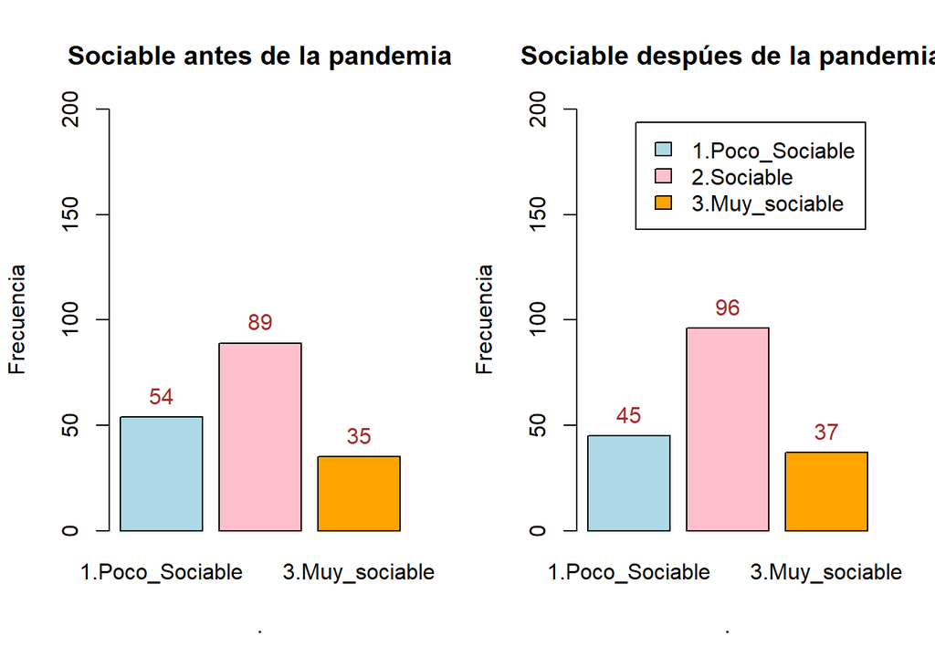

```r
par(mfrow=c(1,2))
Cuentas1 <- table((DFp$Sociable_Antes))


barras1 <- barplot(Cuentas1,
        main = "Sociable antes de la pandemia",
        xlab=".",
        ylab="Frecuencia",
        ylim = c(0, 200),
        col=c("lightblue", "pink","orange")

)
text(x = barras1, y = Cuentas1, pos = 3, cex = 1, col = "brown", label = Cuentas1)

# Crear el segundo gráfico de barras en el segundo panel
Cuentas2 <- table(DFp$Sociable_despues)
barras2 <- barplot(Cuentas2,
                   main = " Sociable despúes de la pandemia",
                   xlab = ".",
                   ylab = "Frecuencia",
                   legend = rownames(Cuentas2),
                   ylim = c(0, 200),
                   col = c("lightblue", "pink", "orange")
)


# Agregar etiquetas de frecuencia para el primer gráfico
text(x = barras1, y = Cuentas2, pos = 3, cex = 1, col = "brown", label = Cuentas2)
```

Interpretación:

En este gráfico se comparan 2 variables, que tan sociable te consideras de antes de pandemia y que tan sociable te consideras después de la pandemia, se puede observar que hubo una reducción de 54 a 45 votos en los que se consideraban poco sociable y ha aumentado los que se consideran sociables de 89 a 96 y muy sociables de 35 a 37 después de la pandemia. Esto se relaciona con nuestro primer objetivo general que nos ayuda a analizar la influencia que tuvo la tecnología en el entorno de los estudiantes del periodo 2023-1, viendo que al estar relacionándose en un ambiente casi en su totalidad virtual se volvieron más sociables, lo que nos hace pensar que los estudiantes al tener una influencia de la tecnología al estar en un entorno social virtual mejoran sus habilidades sociales de los estudiantes del periodo 2023-1.

## 2.4 BOXPLOT: Tiempo de socializar(virtual-presencial) y Manera de socializar

```r
library(ggplot2)
```

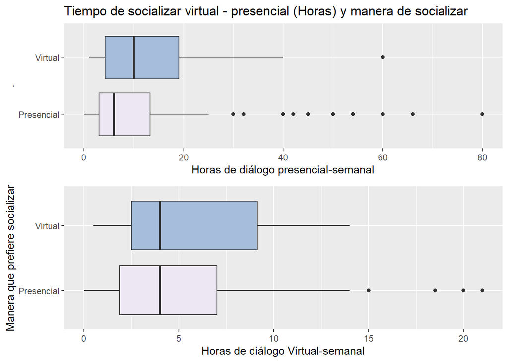

```r
p1<-ggplot(DFp, aes(x = DFp$Manera_socializar, y =DFp$Dialogo_amigos_presencial,fill=DFp$Manera_socializar )) + scale_fill_brewer(palette="PuBu")  +
 labs(x='.', y='Horas de diálogo presencial-semanal') +

  ggtitle("Tiempo de socializar virtual - presencial (Horas) y manera de socializar")+
  geom_boxplot()

p3<-p1 + theme(legend.position = "none")

p4<-p3+  coord_flip()


p2<-ggplot(DFp, aes(x = DFp$Manera_socializar, y =DFp$Dialogo_amigos_virtual,fill=DFp$Manera_socializar )) + scale_fill_brewer(palette="PuBu")  +
 labs(x='Manera que prefiere socializar', y='Horas de diálogo Virtual-semanal', xlim=c(0,80)) +
  geom_boxplot()
p6<-p2 + theme(legend.position = "none")

p7<-p6+  coord_flip()

require(gridExtra)
grid.arrange(p4,p7,nrow=2)
```